# Analysis of Tronix token data

Kavya Jampani,Beryl Mario Shairu Joseph Antony Bose

### Ethereum and ERC-20 tokens

Ethereum was proposed by Vitalik Buterin, a cryptocurrency researcher and programmer. It is a distributed public blockchain framework which uses the block chain technology to create smart contracts to provide provide a static and consistent transactions record.

Although commonly associated with bitcoin, there are significant technical differences between the two. There is a substantial difference in both in terms of purpose and capability. Ethereum enables developers to build and deploy any decentralized application whereas Bitcoin offers one particular application of blockchain technology i.e, a peer-to-peer electronic cash system that enables online bitcoin payments. In Ethereum blockchain, miners work to earn Ether, a type of crypto token that fuels the network. Ethereum is also used a platform to launch other cryptocurrencies

The benefits of the Ethereum decentralized platform are as follows:  
Immutability - A third party cannot make any changes to the data.  
Corruption and Tamper proof - Apps are based on a network formed around the principle of consensus, making censorship impossible.  
Secure- With no central point of failure and secured with cryprography, applications on this framework are well protected against hacking attacks and fraudulent activities.  
Zero downtime - Applications can never go down and can never be switched off.

Token:  
In general sense, a token is used to describe any digital asset. They serve as the transaction units on the blockchains that are created using the standard templates like that of Ethereum network, where user can create his own tokens.

ERC-20 Tokens:  
These are the tokens designed solely for the usage on Ethereum platform. ERC-20 is a technical standard used for smart contracts on the Ethereum blockchain for implementing tokens. It defines a common list of rules that an Ethereum token has to implement, giving developers the ability to program how new tokens will function within Ethereum ecosystem. According to Etherscan.io there are a total of 103621 of ERC-20 commpatible tokens found on Ethereum main network as of 07-26-2018. Because of ERC-20 token standard definition other developers can issue their own versions of the token and raise funds with an initial coin offering (ICO).  
Depending on its purpose, decentralized applications might use ERC-20 tokens to function as a currency, a share in a company or even proof of ownership. These tokens are created using smart contracts. ERC-20 makes the creation of new tokens extremely easy, and that is why Ethereum has become most popular platform for ICO’s in 2017.

### Primary Token

In our project we have considered Tronix token which is based on ERC-20 Ethereum standard.  
About the token:  
TRON Foundation was established in september 2017 by Justin Sun.TRX is the cryptographic currency developed by TRON,which aims to be a decentralized entertainment content sharing platform using blockchain and peer-to-peer network technology. In 2018 TRON launched its own proprietary blockchain, Mainnet to which it migrated all the TRX (ERC-20) tokens that previously circulated on the Ethereum blockchain. In February 2018, TRX was ranked 15th on the list of largest cryptocurrencies by market capitalization.TRON Foundation seeks to tackle the global entertainment industry â currently valued at $1 trillion. Bit-Z, Liqui, and Gatecoin are the next three biggest TRX exchanges.

Major features of TRON are :  
-Uncontrolled and free data  
-Using content spreading, to enable content ecosystem, where users ca obtain digital assets.  
-Initial Coin Offering to distribute the digital assets  
-Framework to allow distributed digital assets exchange (such as games) and market forecasting.

### Scope

In this project, we examined the Ethereum dataset: Tronix(TRX). We have preprocessed the data removing the outliers where the transactions are impossible and then identified the distributions of number of user transactions by buyer and number of user transactions by the seller. Then we tried to find the correlation of the number of users made transactions on a specific date with the closing price on the same date.

### Data Set

The dataset we have considered has two files:  
Token edge file which has 1,51,8537 transactions. This set has the row structure of “fromNodeID NodeID unixTime tokenAmount”" which implies that fromNodeId sold tokenAmount of the token to toNodeId at time unixTime. Each token has a total circulating amount and subunits. For our token the value is 100000000000 (according to coinmarketcap.com) and has 10e+06 subunits.

Token price file which has 254 rows and the row structure is “Date Open High Low Close Volume MarketCap”" which provides the price data on a specific date. Open and Close are the prices of the token at the given date. Volume and MarketCap give total bought/sold tokens and market valuation at that date.

### Preprocessing the data

Based on the total supply value of the tronix token, we have removed the outliers which are greater than totalAmount*subunits. There are 65 transactions where the token amount is greater than the totalsupply*subunits and 41 unique users are involved in these transactions.

```r
df <- read.table("C:/Users/Administrator/Downloads/Stats_project/networktronixTx.txt", quote="\"", comment.char="")
names(df) <- c("fromId","toId","time","tokenAmount")
totalsupply <- 100000000000
subunits <- 10e+06
threshold <- totalsupply*subunits
```

### Distribution of how many times user buys a token

To observe the behaviour of number of times user buys a token, we have derived frequencies for each user and then plotted the distribution of frequencies against user counts.As most of the data belongs to smaller frequencies, we have limited the set to see the behaviour of the dataset. For this we have considered the subset of data where user counts<= 600. This results in a set of 97% data excluding 10 outliers. We have used ggplot2 package of R for visualization.

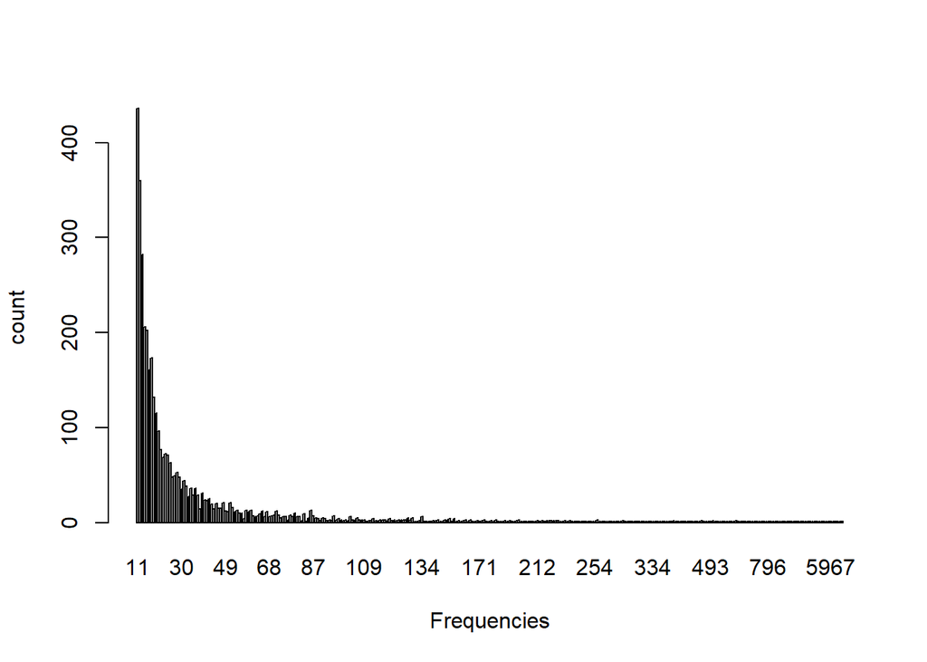

```r
library(ggplot2)
library(dplyr)
library(fitdistrplus)
library(lubridate)
data1 <- subset(df,df$tokenAmount <= threshold)
df3 <- as.data.frame(table(data1$toId))
names(df3) <- c("toId","freq")
df3s <- as.data.frame(table(df3$freq))
names(df3s) <- c("freq","nuser")
df3s1 <- subset(df3s,df3s$nuser <= 600)
barplot(df3s1$nuser,names.arg=df3s1$freq,xlab="Frequencies",ylab="count")
```

The parameters of the data are  
Mean : 12.8169935  
Median : 2  
Variance : 1906.090989  
Standard Devation : 43.658802

‘Cullen and Frey Graph’ gives the summary of best distributions that can fit the data From the below graph, we can see that normal,negative binomial and poisson distributions fit the data better. We have used ‘fitdistrplus’ package of R for the data visualization.

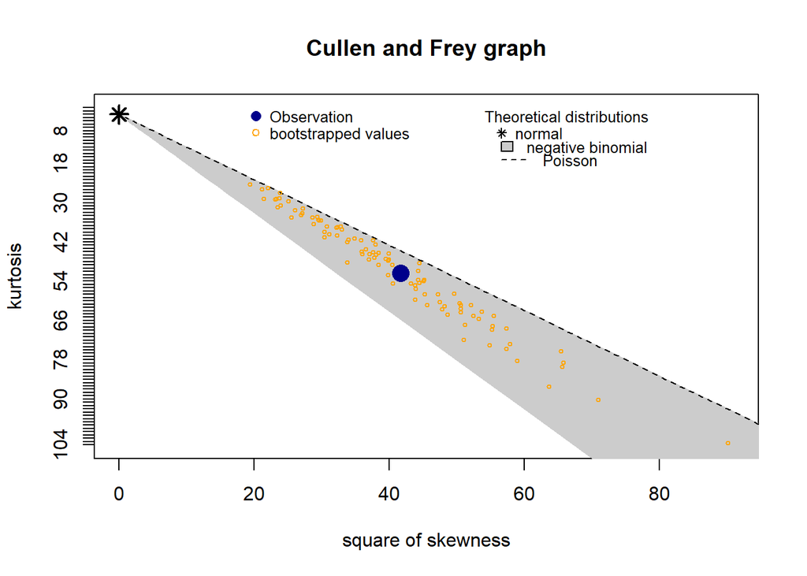

```
## summary statistics
## ------
## min:  1   max:  436
## median:  2
## mean:  12.81699
## estimated sd:  43.6588
## estimated skewness:  6.454679
## estimated kurtosis:  51.59676
```

```r
descdist(df3s1$nuser, discrete = TRUE, boot = 100)
```

Cumulative Distribution Function (CDFs) have most meaning for visualizing the discrete fits. The CDFs of the above distributions are as follows.

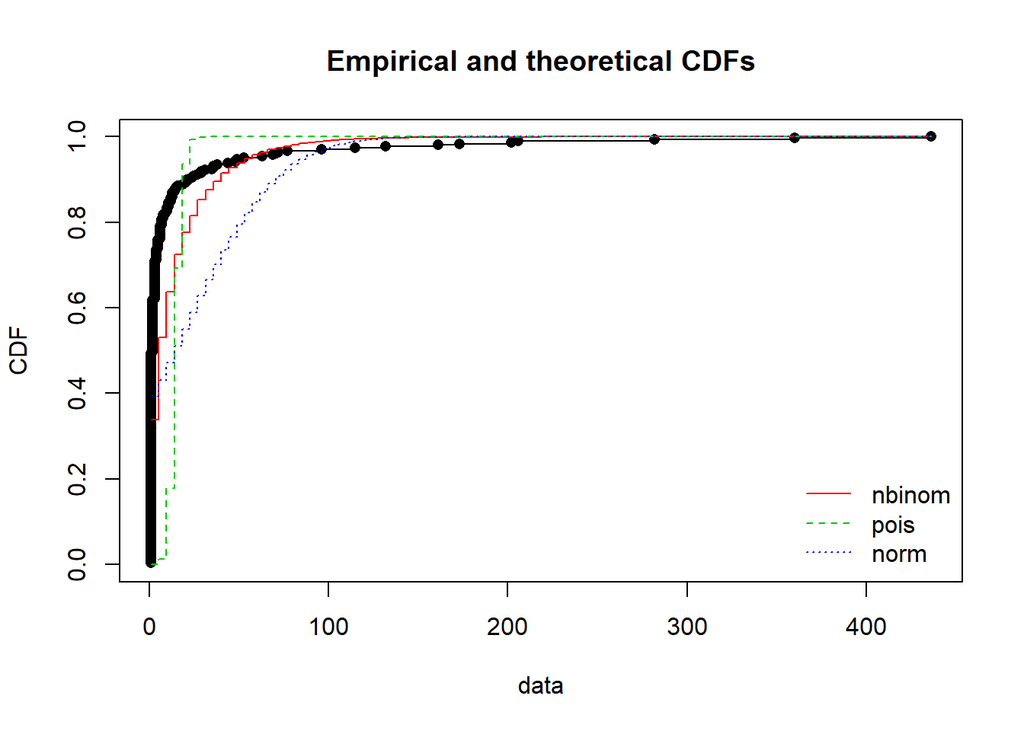

```r
f1n <- fitdist(df3s1$nuser,"nbinom")
f2n <- fitdist(df3s1$nuser,"pois")
f3n <- fitdist(df3s1$nuser,"norm")
plot.legend <- c("nbinom","pois","norm")
cdfcomp(list(f1n,f2n,f3n), legendtext = plot.legend)
```

The Goodness-of-fit criteria is calculated by using the gofstat() function in R.

```r
gofstat(list(f1n, f2n,f3n))
```

```
## Chi-squared statistic:  88.05693 2079828 817.857
## Degree of freedom of the Chi-squared distribution:  4 5 4
## Chi-squared p-value:  3.405395e-18 0 1.040706e-175
##    the p-value may be wrong with some theoretical counts < 5
## Chi-squared table:
##       obscounts theo 1-mle-nbinom theo 2-mle-pois theo 3-mle-norm
## <= 1        151         103.41114    1.147586e-02      120.304852
## <= 2         38          19.96252    6.822039e-02        2.707841
## <= 3         28          15.52547    2.914601e-01        2.723302
## <= 6         25          33.33308    8.441844e+00        8.249032
## <= 12        20          40.35453    1.390947e+02       16.726934
## <= 29        19          52.16536    1.580833e+02       46.592076
## > 29         25          41.24791    9.014495e-03      108.695964
##
## Goodness-of-fit criteria
##                                1-mle-nbinom 2-mle-pois 3-mle-norm
## Akaike's Information Criterion     2003.639   14488.51   3182.549
## Bayesian Information Criterion     2011.087   14492.23   3189.996
```

The AIC and BIC count are minimum for the negative binomial distribution.So, we can say that negative binomial distribution fits the data better.The estimated parameter of the distribution is as follows

```r
f1n
```

```
## Fitting of the distribution ' nbinom ' by maximum likelihood
## Parameters:
##        estimate Std. Error
## size  0.4073471 0.02844392
## mu   12.8168164 1.16607164
```

Modelling negative binomial:  
We can see the estimated mean is same as the mean we got from the sample. The probability of success can be calculated by  
p = size/mu = 0.032  
standard deviation = size(1-p)/p^2 = 19.76

## Distribution of how many times user sells the data

To observe the behaviour of number of times user sells a token, we have derived frequencies for each user and then plotted the distribution of frequencies against user counts.As most of the data belongs to smaller frequencies, we have limited the set to see the behaviour of the dataset. For this we have considered the subset of data where user counts<= 100. This results in a set of 99.4% data excluding 2 outliers.

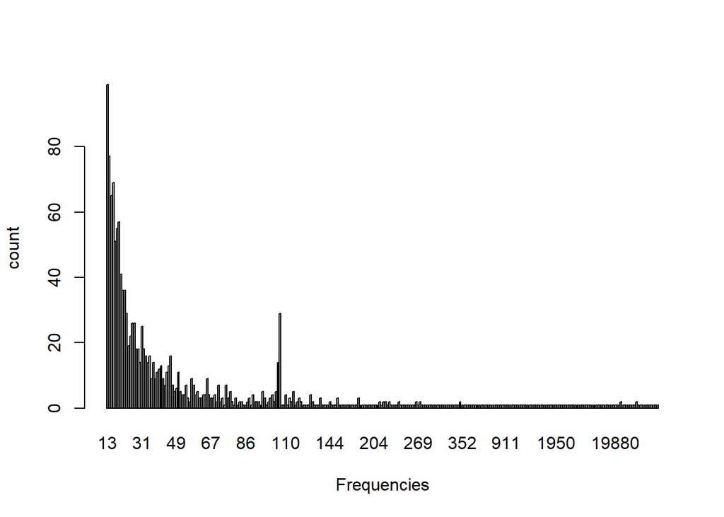

```r
df4 <- as.data.frame(table(data1$fromId))
names(df4) <- c("fromId","freq")
df4s <- as.data.frame(table(df4$freq))
names(df4s) <- c("freq","nuser")
df4s$freq<-as.numeric(as.character(df4s$freq))
df4s1 <- subset(df4s,df4s$nuser <= 100)
barplot(df4s1$nuser,names.arg=df4s1$freq,xlab="Frequencies",ylab="count")
```

The parameters of the data are

Mean : 5.0243056

Median : 1

Variance : 139.3269333

Standard Devation : 11.803683

From the below graph, we can see that negative binomial,normal and poisson distributions fit the data better.

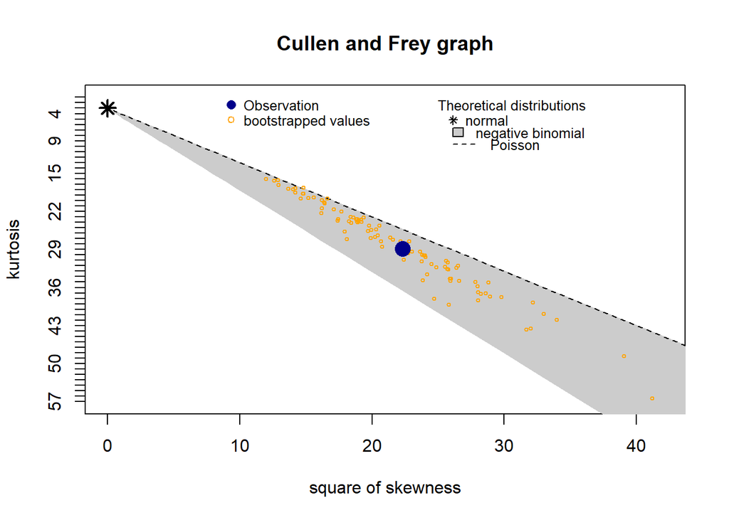

```
## summary statistics
## ------
## min:  1   max:  99
## median:  1
## mean:  5.024306
## estimated sd:  11.80368
## estimated skewness:  4.722361
## estimated kurtosis:  28.85259
```

```r
descdist(df4s1$nuser, discrete = TRUE, boot = 100)
```

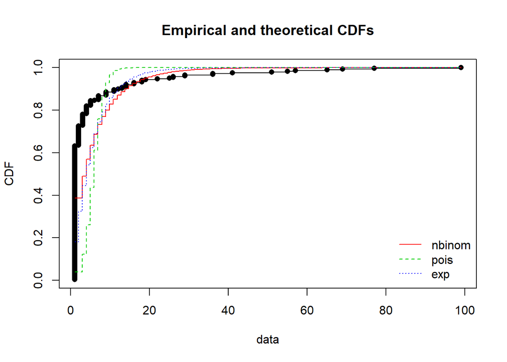

```r
f1n <- fitdist(df4s1$nuser,"nbinom",discrete=TRUE)
f2n <- fitdist(df4s1$nuser,"pois",discrete=TRUE)
f3n <- fitdist(df4s1$nuser,"exp",discrete=TRUE)
plot.legend <- c("nbinom","pois","exp")
cdfcomp(list(f1n,f2n,f3n), legendtext = plot.legend)
```

The Goodness-of-fit criteria results are:

```r
gofstat(list(f1n, f2n,f3n))
```

```
## Chi-squared statistic:  86.05298 2393561 428.2592
## Degree of freedom of the Chi-squared distribution:  3 4 4
## Chi-squared p-value:  1.542119e-18 0 2.174736e-91
##    the p-value may be wrong with some theoretical counts < 5
## Chi-squared table:
##       obscounts theo 1-mle-nbinom theo 2-mle-pois theo 3-mle-exp
## <= 1        182         111.52868    1.140962e+01      51.977297
## <= 2         27          29.51468    2.390487e+01      42.596605
## <= 4         27          41.67036    9.032230e+01      63.517572
## <= 9         19          55.70855    1.529404e+02      81.886098
## <= 19        17          37.15041    9.422708e+00      41.460113
## > 19         16          12.42733    1.070738e-04       6.562314
##
## Goodness-of-fit criteria
##                                1-mle-nbinom 2-mle-pois 3-mle-exp
## Akaike's Information Criterion     1533.564   4075.952  1507.829
## Bayesian Information Criterion     1540.890   4079.615  1511.492
```

The AIC and BIC count are minimum for the exponential distribution.So, we can say that exponential distribution fits the data better.

```
## Fitting of the distribution ' exp ' by maximum likelihood
## Parameters:
##       estimate Std. Error
## rate 0.1990325 0.01172781
```

## Correlation of number of users and price on a specific date

To find the behaviour of number of users doing transactions on a particular date, we have plotted the graph of number of users against date.

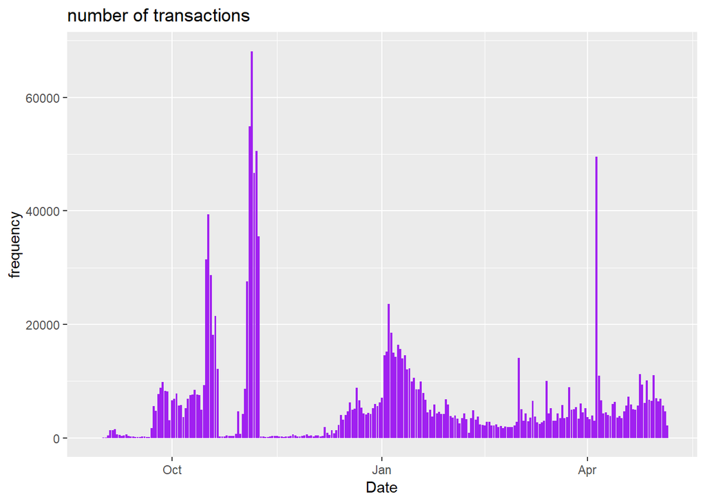

```r
data1["date"] = as.Date(as.POSIXct(as.numeric(as.character(data1$time)),origin="1970-01-01",tz="GMT"))
dg <- group_by(data1,date)
data_grp <- tally(dg)
names(data_grp) <- c("date","freq")
ggplot(data = data_grp, aes(x = date, y = freq)) +
      geom_bar(stat = "identity", fill = "purple") +
      labs(title = "number of transactions",x = "Date", y = "frequency")
```

The following is the barplot with date on the x axis and price on y axis. The price behaviour of the tronix token can be observed from the following plot:

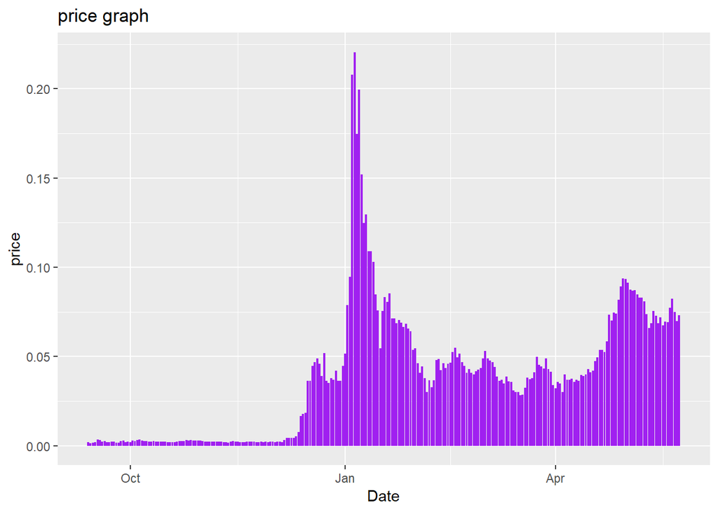

```r
pricedata <- read.table("C:/Users/Administrator/Downloads/Stats_project/Tronix.txt",sep="\t",comment.char="",header=TRUE)
pricedata["date1"] <- as.Date(parse_date_time(pricedata$Date,"mdy"))
ggplot(data = pricedata, aes(x = date1, y = Close)) +
      geom_bar(stat = "identity", fill = "purple") +
      labs(title = "price graph",x = "Date", y = "price")
```

We have merged the grouped data and the pricedata on date and we have obtained the correlation value of 0.14(approximate) for the number of transactions on a date and the closing price of the date.

```r
merge_data = merge(x=data_grp,y=pricedata,by.x="date",by.y="date1")
cor(merge_data$freq,merge_data$Close,method="pearson")
```

```
## [1] 0.135552
```

```r
head(merge_data,30)
```

```
##          date freq       Date     Open     High      Low    Close
## 1  2017-09-13  250  9/13/2017 0.002051 0.002448 0.001711 0.001988
## 2  2017-09-14  205  9/14/2017 0.002006 0.002479 0.001298 0.001427
## 3  2017-09-15  119  9/15/2017 0.001419 0.001831 0.001091 0.001801
## 4  2017-09-16  106  9/16/2017 0.001815 0.017671 0.001371 0.001831
## 5  2017-09-17  107  9/17/2017 0.001836 0.003879 0.001781 0.003320
## 6  2017-09-18  263  9/18/2017 0.003324 0.003438 0.002534 0.003263
## 7  2017-09-19  204  9/19/2017 0.003273 0.023238 0.001746 0.002291
## 8  2017-09-20  176  9/20/2017 0.002306 0.003199 0.002039 0.002647
## 9  2017-09-21  165  9/21/2017 0.002638 0.003173 0.001935 0.002079
## 10 2017-09-22 1695  9/22/2017 0.002079 0.002172 0.001852 0.001951
## 11 2017-09-23 5559  9/23/2017 0.001934 0.002346 0.001924 0.002346
## 12 2017-09-24 4781  9/24/2017 0.002346 0.002427 0.002086 0.002246
## 13 2017-09-25 7748  9/25/2017 0.002251 0.005656 0.001465 0.001777
## 14 2017-09-26 8808  9/26/2017 0.001777 0.002104 0.001619 0.001738
```

[output cut: 47 more lines]

To find the correlation for different layers of data, we have divided the dataset into 11 layers and the correlation values for each of the layer are as follows

```r
x <- 1.373e+05
y <- 1
a <- 0
i <- 1
while(x <= 1.000e+16)
{
  dfp <- subset(data1, data1$tokenAmount < x & data1$tokenAmount > y)
  dg <- group_by(dfp,date)
  data_grp <- tally(dg)
  names(data_grp) <- c("date","freq")
  merge_data = merge(x=data_grp,y=pricedata,by.x="date",by.y="date1")
  a[i] <- cor(merge_data$freq,merge_data$Close,method="pearson")
  message("The correlation value of layer ",i," is : ",a[i])
  y <- x
  x <- x*10
  i <- i+1
}
```

```
## The correlation value of layer 1 is : -0.340183485518905
```

```
## The correlation value of layer 2 is : -0.26430244634645
```

```
## The correlation value of layer 3 is : -0.272783819653525
```

```
## The correlation value of layer 4 is : 0.74521142354488
```

```
## The correlation value of layer 5 is : 0.893549682853852
```

```
## The correlation value of layer 6 is : 0.838763302838107
```

```
## The correlation value of layer 7 is : 0.460022168369007
```

```
## The correlation value of layer 8 is : 0.533558568063932
```

```
## The correlation value of layer 9 is : 0.380554866602955
```

```
## The correlation value of layer 10 is : 0.137888876586071
```

```
## The correlation value of layer 11 is : -0.0509642651760034
```

We see that layer 5 has maximum correlation with value 0.894(approximate). In this layer there are 126504 transactions and the p-value is 2.2e-16 which is very less indicating that correlation value is different from 0. The maximum correlation value is 0.894(approximate) which is higher than the Standard Statistic Correlation co-efficient Value of 0.5 and more. Inspite of the time span of the tokens being 9 months (2017-08-29 to 2018-05-06), due to the transactions being spread out, it gives a relatively high correlation, hence denotes a strong positive Linear relationship between the variables being - the number of users and price on a specific date. Since the relationship is known to be linear, or the observed pattern etween the two variables appears to be linear, then the correlation coefficient of 0.894 provides a reliable measure of the strength of the linear relationship. This justifies the number (11) we have chosen to obtain layers, which is to maximize correlation, and have achieved the purpose of layering the data in that pattern. The results of using the Pearson correlation are as follows:

```r
  dfp <- subset(data1, data1$tokenAmount < 1.373e+09 & data1$tokenAmount > 137300000)
  dg <- group_by(dfp,date)
  data_grp <- tally(dg)
  names(data_grp) <- c("date","freq")
  merge_data = merge(x=data_grp,y=pricedata,by.x="date",by.y="date1")
  cor.test(merge_data$freq,merge_data$Close,method="pearson")
```

```
##
##  Pearson's product-moment correlation
##
## data:  merge_data$freq and merge_data$Close
## t = 30.445, df = 234, p-value < 2.2e-16
## alternative hypothesis: true correlation is not equal to 0
## 95 percent confidence interval:
##  0.8644938 0.9166538
## sample estimates:
##       cor
## 0.8935497
```

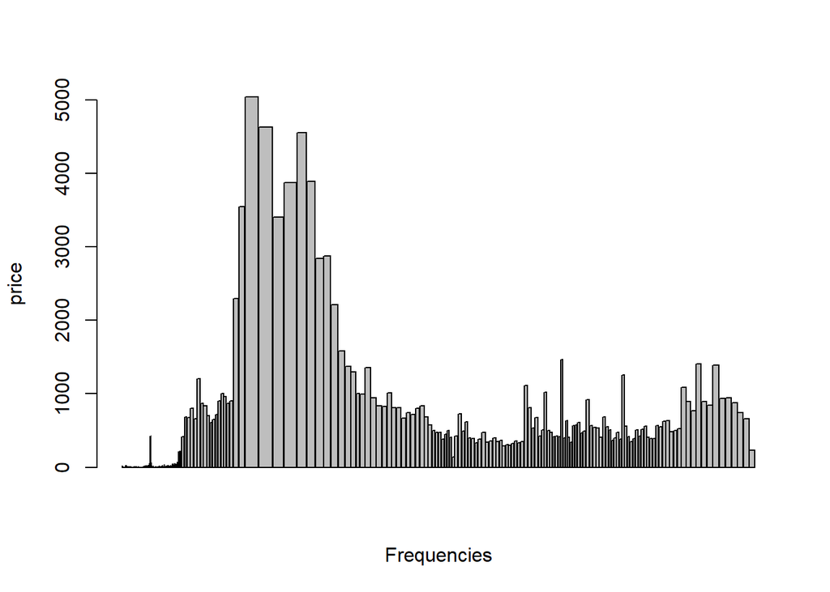

```r
barplot(merge_data$freq,merge_data$Close,xlab="Frequencies",ylab="price")
```

```r
f3n <- fitdistr(merge_data$freq,"normal")
f3n
```

```
##      mean         sd
##   533.73305   788.38304
##  ( 51.31936) ( 36.28827)
```

### Multiple Linear regression Model for the Simple price return

The following is the plot of the growth and the price return. The correlation value is 0.213.

```r
library('useful')
library('lubridate')
## pricereturn and growth in a previous day
pricedata <- read.table("C:/Users/Administrator/Downloads/Stats_project/Tronix.txt",sep="\t",comment.char="",header=TRUE)
pricedata["date1"] <- as.Date(parse_date_time(pricedata$Date,"mdy"))
pricedata <- pricedata[order(pricedata$date1), ]
pd <- shift.column(data=pricedata,columns=c("Market.Cap","Open","High","Low"),up=FALSE)
pd <- subset(pd,pd$date1 >= as.Date("2017-09-30"))
sub1 <- gsub(",","",pd$Market.Cap.Shifted)
pd["market_diff"] = as.numeric(as.character(sub1))/pd$High.Shifted
pd["pricereturn"] = (pd$Open-pd$Open.Shifted)/(pd$Open.Shifted)
pd["growth"] = (pd$High.Shifted-pd$Low.Shifted)
```

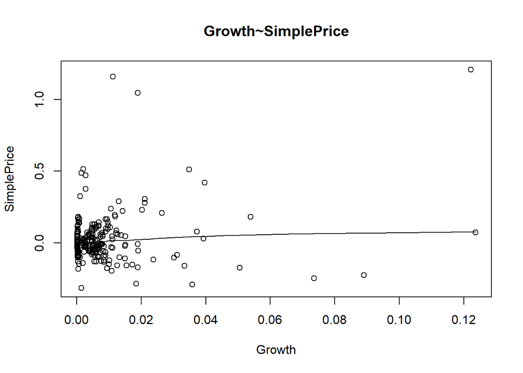

```r
scatter.smooth(x=pd$growth, y=pd$pricereturn, main="Growth~SimplePrice",xlab="Growth",ylab="SimplePrice")
```

```r
cor(pd$growth,pd$pricereturn,method="pearson")
```

```
## [1] 0.2137682
```

The following is the plot of the market value and the price return. The correlation value is -0.532. This shows that price return is negatively correlated to marketvalue/highprice.

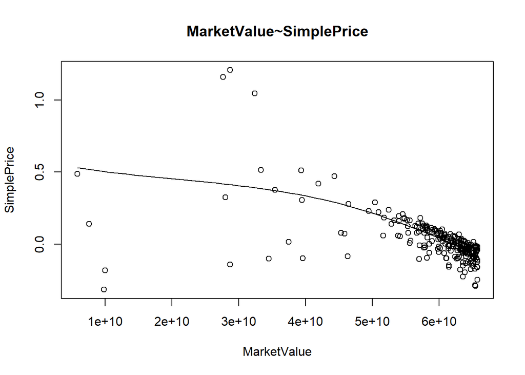

```r
scatter.smooth(x=pd$market_diff, y=pd$pricereturn, main="MarketValue~SimplePrice", xlab="MarketValue", ylab="SimplePrice")
```

```r
cor(pd$market_diff,pd$pricereturn,method="pearson")
```

```
## [1] -0.5317525
```

We have plotted the graph between the number of users buying the tokens on the previous day and the price return value and the plot is shown below. The correlation value here is 0.112.

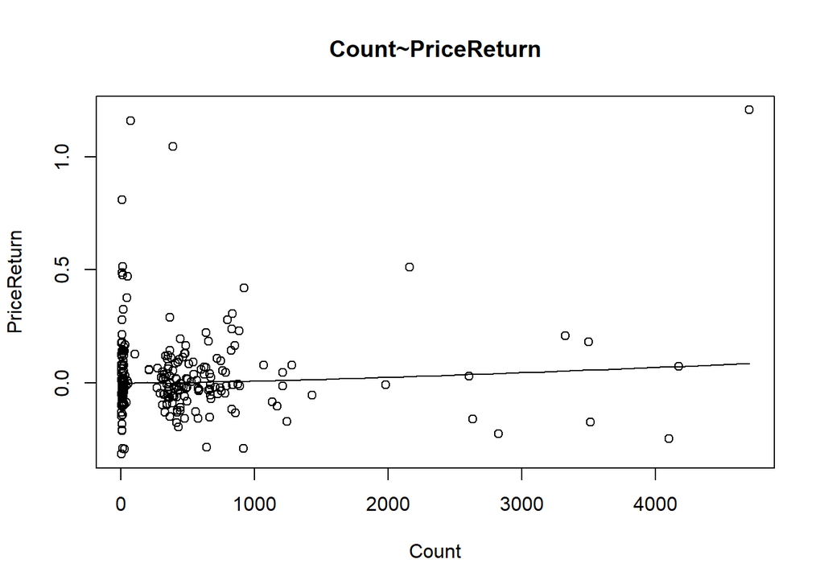

```r
## price and number of unique users buying in a previous day transactions
require(data.table)
data1 <- subset(df, df$tokenAmount < 1.373e+09 & df$tokenAmount > 137300000)
data1["date"] = as.Date(as.POSIXct(as.numeric(as.character(data1$time)),origin="1970-01-01",tz="GMT"))
ans = as.data.table(data1)[, count := uniqueN(toId), by = date]
merge_data = merge(x=ans,y=pricedata,by.x="date",by.y="date1")
merge_d <- unique(subset(merge_data, select = c("date","count","Open","High","Low","Close")))
merge_d <- as.data.frame(shift.column(data=merge_d,columns=c("count","Open"),up=FALSE))
merge_d["pricereturn"] <- (merge_d$Open-merge_d$Open.Shifted)/merge_d$Open.Shifted
scatter.smooth(x=merge_d$count.Shifted, y=merge_d$pricereturn, main="Count~PriceReturn",xlab="Count",ylab="PriceReturn")
```

```r
cor(merge_d$count.Shifted,merge_d$pricereturn,method="pearson")
```

```
## [1] 0.1120185
```

The multiple regression is modelled using lm() function in R. The summary of the linear model is as follows:

```r
finaldata <- merge(x=merge_d,y=pd,by.x="date",by.y="date1")
head(finaldata,5)
```

```
##         date count   Open.x   High.x    Low.x  Close.x count.Shifted
## 1 2017-09-30     8 0.001983 0.002621 0.001763 0.002261             3
## 2 2017-10-01     8 0.002261 0.002269 0.001806 0.001848             8
## 3 2017-10-02     7 0.001848 0.003177 0.001768 0.002803             8
## 4 2017-10-03    18 0.002748 0.003186 0.002128 0.002447             7
## 5 2017-10-04    15 0.002469 0.003521 0.002400 0.003250            18
##   Open.Shifted.x pricereturn.x      Date   Open.y   High.y    Low.y
## 1       0.002901    -0.3164426 9/30/2017 0.001983 0.002621 0.001763
## 2       0.001983     0.1401916 10/1/2017 0.002261 0.002269 0.001806
## 3       0.002261    -0.1826625 10/2/2017 0.001848 0.003177 0.001768
## 4       0.001848     0.4870130 10/3/2017 0.002748 0.003186 0.002128
## 5       0.002748    -0.1015284 10/4/2017 0.002469 0.003521 0.002400
##    Close.y    Volume  Market.Cap Market.Cap.Shifted Open.Shifted.y
## 1 0.002261    53,734  19,966,000         29,208,900       0.002901
## 2 0.001848    72,807  22,765,800         19,966,000       0.001983
## 3 0.002803   887,622  18,600,200         22,765,800       0.002261
## 4 0.002447   822,107 109,938,000         18,600,200       0.001848
## 5 0.003250 1,072,200  98,764,600        109,938,000       0.002748
##   High.Shifted Low.Shifted market_diff pricereturn.y   growth
## 1     0.002973    0.001487  9824722503    -0.3164426 0.001486
## 2     0.002621    0.001763  7617703167     0.1401916 0.000858
## 3     0.002269    0.001806 10033406787    -0.1826625 0.000463
## 4     0.003177    0.001768  5854642745     0.4870130 0.001409
## 5     0.003186    0.002128 34506591337    -0.1015284 0.001058
```

```r
final_data <- subset(finaldata,select=c("date","growth","market_diff","pricereturn.y","count.Shifted"))
linearMod  <- lm(pricereturn.y ~ market_diff+growth+count.Shifted,data = final_data)
summary(linearMod)
```

```
##
## Call:
## lm(formula = pricereturn.y ~ market_diff + growth + count.Shifted,
##     data = final_data)
##
## Residuals:
##      Min       1Q   Median       3Q      Max
## -0.77512 -0.04154  0.00873  0.06394  0.84536
##
## Coefficients:
##                 Estimate Std. Error t value Pr(>|t|)
## (Intercept)    5.449e-01  6.358e-02   8.570 2.02e-15 ***
## market_diff   -9.052e-12  1.071e-12  -8.451 4.36e-15 ***
## growth         1.810e+00  1.515e+00   1.195    0.233
## count.Shifted -5.891e-06  3.259e-05  -0.181    0.857
## ---
## Signif. codes:  0 '***' 0.001 '**' 0.01 '*' 0.05 '.' 0.1 ' ' 1
##
## Residual standard error: 0.1557 on 215 degrees of freedom
## Multiple R-squared:  0.2969, Adjusted R-squared:  0.2871
## F-statistic: 30.26 on 3 and 215 DF,  p-value: 2.327e-16
```

```r
AIC(linearMod)
```

```
## [1] -187.2285
```

```r
BIC(linearMod)
```

```
## [1] -170.2832
```

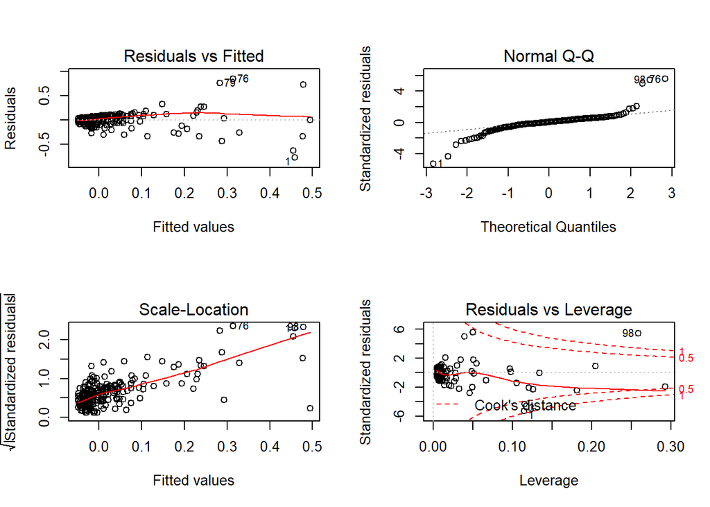

```r
par(mfrow=c(2,2))
plot(linearMod)
```

### Multiple linear regression model for open price

```r
#layer1
data1 <- subset(df, df$tokenAmount < 1.373e+09 & df$tokenAmount > 137300000)
data1["date"] = as.Date(as.POSIXct(as.numeric(as.character(data1$time)),origin="1970-01-01",tz="GMT"))
```

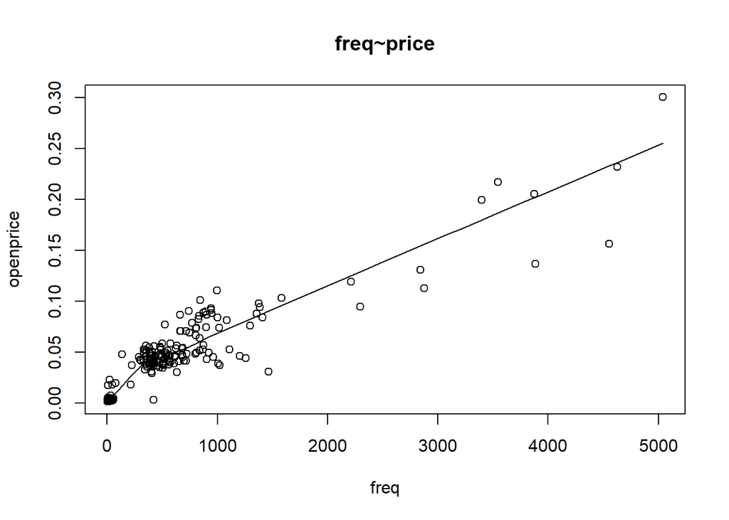

```r
## price and number of transactions in a previous day
library('dplyr')
dg <- group_by(data1,date)
data_grp <- tally(dg)
names(data_grp) <- c("date","freq")
pricedata <- read.table("C:/Users/Administrator/Downloads/Stats_project/Tronix.txt",sep="\t",comment.char="",header=TRUE)
pricedata["date1"] <- as.Date(parse_date_time(pricedata$Date,"mdy"))
data_new <- shift.column(data=data_grp,columns="freq",up=FALSE)
names(data_new) <- c("date","freq","prev_freq")
merge_data = merge(x=data_new,y=pricedata,by.x="date",by.y="date1")
merge_data1 = subset(merge_data,merge_data$prev_freq <= 10000)
scatter.smooth(x=merge_data1$prev_freq, y=merge_data1$High, main="freq~price",xlab="freq",ylab="openprice")
```

```r
cor(merge_data1$prev_freq,merge_data1$Open,method="pearson")
```

```
## [1] 0.9014108
```

We have plotted the graph between the number of unique users and buyers on previous date and the correlation value obtained for them is 0.912

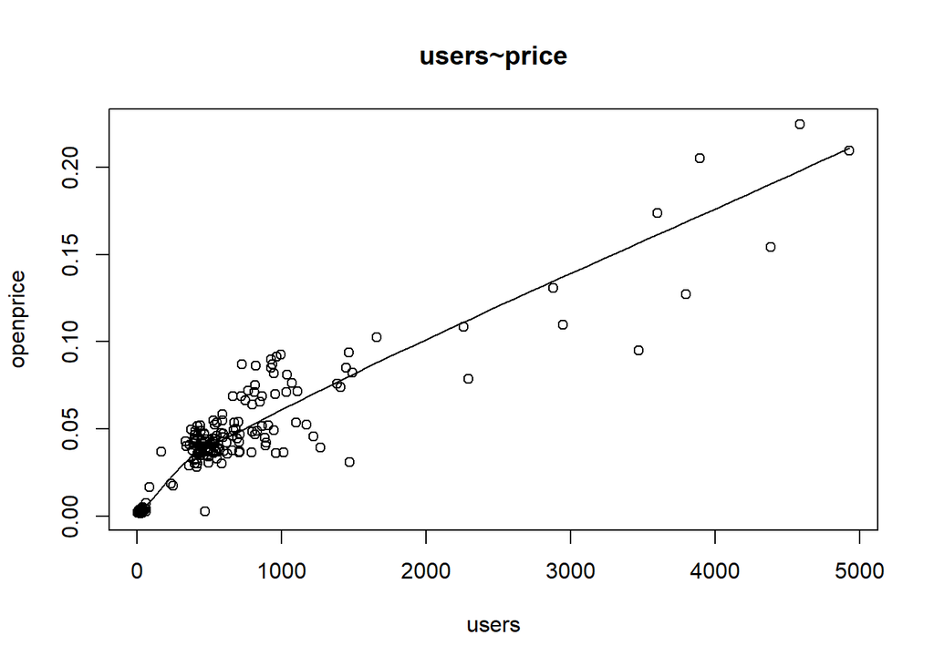

```r
## price and number of unique users selling/buying in a previous day transactions
require(data.table)
ans = as.data.table(data1)[, count := uniqueN(c(fromId,toId)), by = date]
merge_data = merge(x=ans,y=pricedata,by.x="date",by.y="date1")
merge_d <- unique(subset(merge_data, select = c("date","count","Open","High","Low","Close")))
merge_d <- subset(merge_d,merge_d$count<5000)
merge_d <- shift.column(data=merge_d,columns="count",up=FALSE)
scatter.smooth(x=merge_d$count.Shifted, y=merge_d$Open, main="users~price",xlab="users",ylab="openprice")
```

```r
cor(merge_d$count.Shifted,merge_d$Open,method="pearson")
```

```
## [1] 0.9125375
```

The plot shows the relationship between volume of the token on previous date and the opening price. The correlation value of these two variables is 0.85

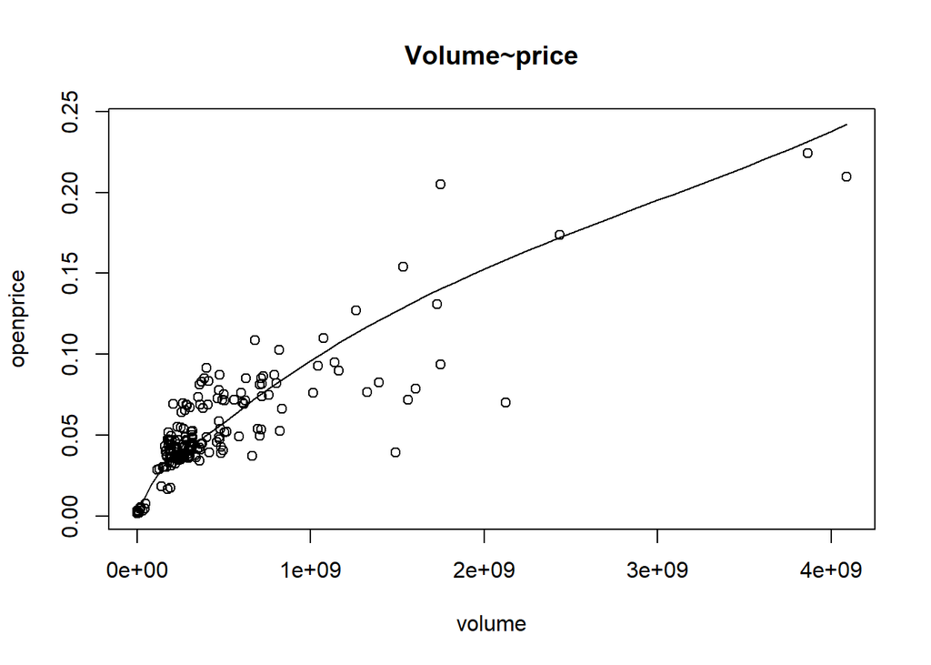

```r
pd <- pricedata[order(pricedata$date1), ]
pd <- shift.column(data=pd,columns="Volume",up=FALSE)
pd$Volume.Shifted <- gsub(",","",pd$Volume.Shifted)
pd$Volume.Shifted <- as.numeric(as.character(pd$Volume.Shifted))
scatter.smooth(x=pd$Volume.Shifted, y=pd$Open, main="Volume~price",xlab="volume",ylab="openprice")
```

```r
cor(pd$Volume.Shifted,pd$Open,method="pearson")
```

```
## [1] 0.8513121
```

The multiple regression is modelled using lm() function in R. The summary of the linear model is as follows:

```r
finaldata <- merge(x=merge_d,y=merge_data1,by.x="date",by.y="date")
finaldata <- subset(finaldata,select=c("date","count.Shifted","Open.x","prev_freq"))
final_data <- merge(x=finaldata,y=pd,by.x="date",by.y="date1")
final_data <- subset(final_data,select=c("date","count.Shifted","Open.x","prev_freq","Volume.Shifted"))
names(final_data) <- c("Date","Prev_Count","Open_Price","Prev_Freq","Prev_Volume")
linearMod  <- lm(Open_Price ~ Prev_Count+Prev_Freq+Prev_Volume,data = final_data)
summary(linearMod)
```

```
##
## Call:
## lm(formula = Open_Price ~ Prev_Count + Prev_Freq + Prev_Volume,
##     data = final_data)
##
## Residuals:
##       Min        1Q    Median        3Q       Max
## -0.038264 -0.007585 -0.003144  0.006763  0.039494
##
## Coefficients:
##               Estimate Std. Error t value Pr(>|t|)
## (Intercept)  8.058e-03  1.107e-03   7.277 5.30e-12 ***
## Prev_Count   2.150e-04  2.307e-05   9.320  < 2e-16 ***
## Prev_Freq   -1.799e-04  2.239e-05  -8.036 4.76e-14 ***
## Prev_Volume  1.466e-11  3.343e-12   4.384 1.77e-05 ***
## ---
## Signif. codes:  0 '***' 0.001 '**' 0.01 '*' 0.05 '.' 0.1 ' ' 1
##
## Residual standard error: 0.01265 on 231 degrees of freedom
## Multiple R-squared:  0.8866, Adjusted R-squared:  0.8852
## F-statistic: 602.2 on 3 and 231 DF,  p-value: < 2.2e-16
```

```r
AIC(linearMod)
```

```
## [1] -1381.236
```

```r
BIC(linearMod)
```

```
## [1] -1363.938
```

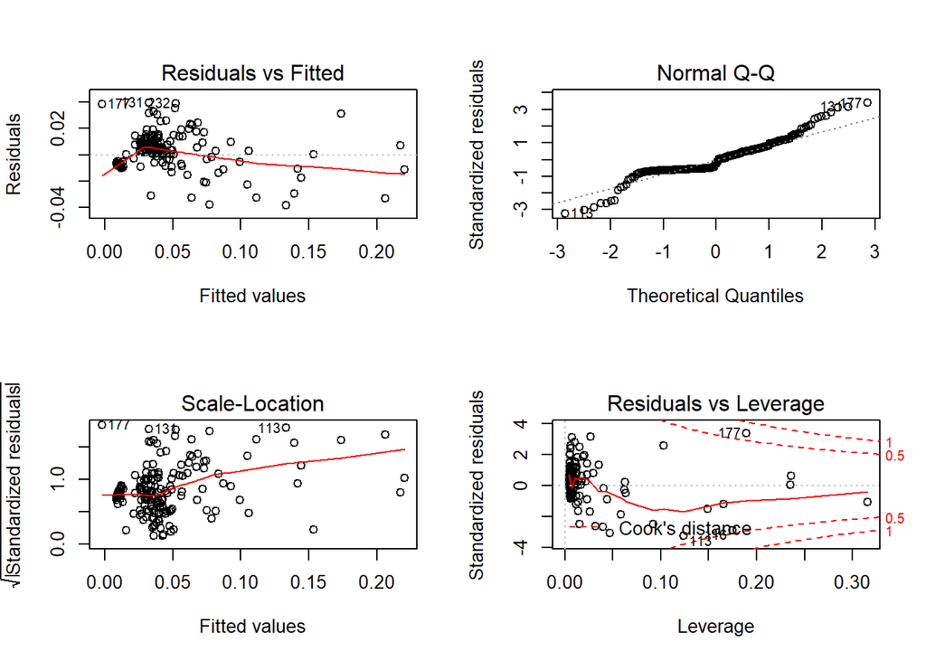

```r
par(mfrow=c(2,2))
plot(linearMod)
```

### Conclusion

Based on the data analysis performed, we found that distribution of number of user buys follows negative binomial distribution and number of times user sells follows exponential distribution. From the layers of the data created, we have found that in layer5 the number of users have strong correlation with price data. The value of 0.89 shows the high correlation value, where the value usually ranges from -1 to 1. We have created a multiple linear regression model on the layer which has 126504 transactions using the features which has maximum correlation with the simple price return and analyzed the results.

### References

https://en.wikipedia.org/wiki/Ethereum https://blockgeeks.com/guides/what-is-ethereum/  
https://blog.coindirect.com/coin-profile-tron-tronix-trx/  
https://developers.tron.network/docs/getting-started  
https://www.inverse.com/article/39961-tron-trx-cryptocurrency-ripple-bitcoin https://blockonomi.com/tron-trx-guide/